# true_fake_news_randomForest

模拟对一个新闻进行判断其是真新闻还是假新闻，主要步骤如下： 1-1.背景分析 1-2.判定与假设 1-3.准备工作 2-1.数据导入 2-2.数据检查 2-3.数据处理与可视化 3-1.特征分析 3-2.特征处理可视化 4.模型选择与训练 5.测试模型与总结

1.1背景分析

为什么要判别新闻的真假？ 1’虚假新闻具有误导性，容易使人产生错误判断。 2‘虚假新闻可能会损害个人或团体的名誉，甚至可能引发社会不公。通过判别真假新闻，我们可以维护公正，保护无辜者免受伤害。 3‘真实的新闻是知识和信息的重要来源，通过判别真假新闻，可以确保获取的信息是准确和有用的。 总之，进行真假新闻的判别对于我们生活在这个信息爆炸的时代来说，是非常必要的。我们需要批判性地思考，检查信息的来源，验证事实，以便我们能够做出基于真实信息的决策。

1-2.判定与假设

通过观察数据集True.csv和Fake.csv发现一共有4个变量，分别为title,text,subject,date即新闻的标签、文本、分类和发布日期 无论真假新闻，最关键的部分都是文本内容和标题，所以后续工作要有意识地关注这两个部分，突破口很有可能在这里找到，关于类别和日期，因为无论什么类别的新闻、什么时候发布的新闻，其真假都是不确定的，或许这两个变量对真假新闻的判别或许作用不大甚至会影响结果。

1.3准备工作

首先引入需要使用的包：数据处理库、sklearn算法库、绘图工具 再从本地将数据集导入

```python
import numpy as np
import pandas as pd
import matplotlib.pyplot as plt
from matplotlib.font_manager import FontProperties
import nltk
from nltk.corpus import stopwords
from collections import Counter
from wordcloud import WordCloud

from sklearn.model_selection import train_test_split
from sklearn.feature_extraction.text import TfidfVectorizer
from sklearn.metrics import accuracy_score

from sklearn.naive_bayes import MultinomialNB
from sklearn.linear_model import LogisticRegression
from sklearn.tree import DecisionTreeClassifier
from sklearn.ensemble import RandomForestClassifier
font = FontProperties(fname=r'D:\jyp\msyh.ttf', size=12)
```

2-1.数据导入 从本地导入数据集True.csv和Fake.csv

```python
true_df = pd.read_csv('D:\jyp\True.csv')
fake_df = pd.read_csv('D:\jyp\Fake.csv')
```

2-2.数据检查

查看数据集中每一列代表什么元素，有没有空值即数据缺失

```python
true_df.isnull().sum()
```

```
title      0
text       0
subject    0
date       0
dtype: int64
```

```python
fake_df.isnull().sum()
```

```
title      0
text       0
subject    0
date       0
dtype: int64
```

设定true、fake数据集的标签，真0假1； 合并两个数据集并打乱，打印出基本信息和前十行数据进行检查

```python
true_df['label'] = 0
fake_df['label'] = 1

df = pd.concat([true_df, fake_df])
df = df.sample(frac=1).reset_index(drop=True)

print(df.info())
df.head(10)
```

```
<class 'pandas.core.frame.DataFrame'>
RangeIndex: 44898 entries, 0 to 44897
Data columns (total 5 columns):
 #   Column   Non-Null Count  Dtype
---  ------   --------------  -----
 0   title    44898 non-null  object
 1   text     44898 non-null  object
 2   subject  44898 non-null  object
 3   date     44898 non-null  object
 4   label    44898 non-null  int64
dtypes: int64(1), object(4)
memory usage: 1.7+ MB
None
```

|  | title | text | subject | date | label |
| --- | --- | --- | --- | --- | --- |
| 0 | Crimean Tatar leader jailed for stirring anti-... | SIMFEROPOL, Crimea (Reuters) - A man who led p... | worldnews | September 11, 2017 | 0 |
| 1 | Police arrest two more men over London train b... | LONDON (Reuters) - British police said they ha... | worldnews | September 20, 2017 | 0 |
| 2 | Trump shows interest in bipartisan tax reform ... | WASHINGTON (Reuters) - President Donald Trump ... | politicsNews | September 26, 2017 | 0 |
| 3 | Turkey's Justice Ministry says it canceled del... | ISTANBUL (Reuters) - Turkey s Justice Ministry... | worldnews | October 24, 2017 | 0 |
| 4 | Powerful Afghan regional leader ousted as poli... | KABUL (Reuters) - One of Afghanistan s most po... | worldnews | December 18, 2017 | 0 |
| 5 | UK PM May: We will not revoke Article 50 EU ex... | LONDON (Reuters) - Britain will not revoke the... | worldnews | October 9, 2017 | 0 |
| 6 | Josh Groban Mocks The Hell Out Trump Meeting ... | Because nothing in this world makes sense anym... | News | December 13, 2016 | 1 |
| 7 | THE PURGE: NYC Mayor De Blasio to Review ‘All ... | THE PURGE CONTINUES THE NYC MAYOR has just ope... | left-news | Aug 16, 2017 | 1 |
| 8 | Trump tells Congress: 'Get ready to do your jo... | WASHINGTON (Reuters) - U.S. President Donald T... | politicsNews | September 5, 2017 | 0 |
| 9 | Alt-Right ‘Enemies’ List LEAKED: Fascists Use... | Last night Buzzfeed reported that a massive do... | News | May 22, 2017 | 1 |

2-3.数据处理与可视化

绘制真、假新闻中新闻类别的横向直方图

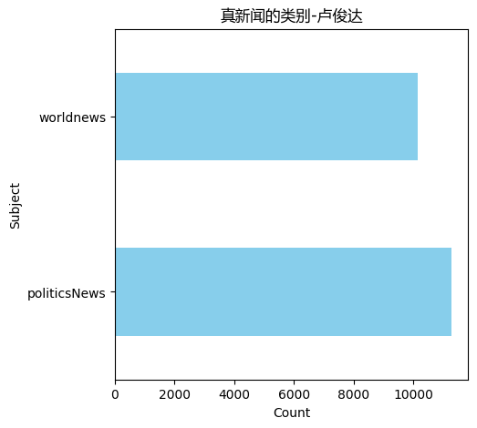

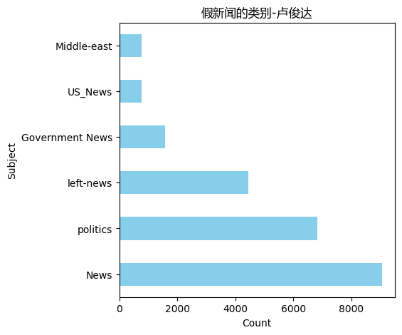

```python
# 从True.csv和Fake.csv中分别提取subject列
true_subjects = true_df['subject']
fake_subjects = fake_df['subject']

# 统计元素种类和个数
true_subject_counts = true_subjects.value_counts()
fake_subject_counts = fake_subjects.value_counts()

# 绘制True.csv的横向直方图
plt.figure(figsize=(5,5))
true_subject_counts.plot(kind='barh', color='skyblue')
plt.xlabel('Count')
plt.ylabel('Subject')
plt.title('真新闻的类别-卢俊达', fontproperties=font)
plt.show()

# 绘制Fake.csv的横向直方图
plt.figure(figsize=(5,5))
fake_subject_counts.plot(kind='barh', color='skyblue')
plt.xlabel('Count')
plt.ylabel('Subject')
plt.title('假新闻的类别-卢俊达', fontproperties=font)
plt.show()
```

绘制真、假新闻中发布年份的横向直方图

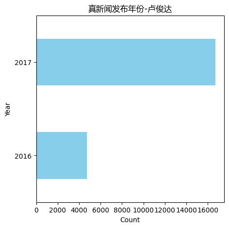

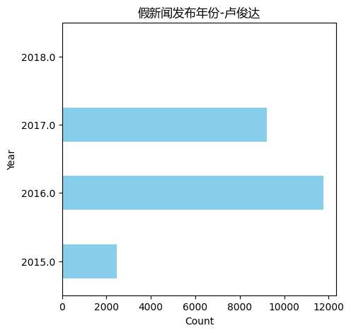

```python
import matplotlib.pyplot as plt

# 从True.csv和Fake.csv中分别提取date列，并转换为datetime类型
true_dates = pd.to_datetime(true_df['date'], format="mixed", errors='coerce')
fake_dates = pd.to_datetime(fake_df['date'], format="mixed", errors='coerce')

# 提取年份
true_years = true_dates.dt.year
fake_years = fake_dates.dt.year

# 统计元素种类和个数
true_year_counts = true_years.value_counts().sort_index()
fake_year_counts = fake_years.value_counts().sort_index()

# 绘制True.csv的横向直方图
plt.figure(figsize=(5,5))
true_year_counts.plot(kind='barh', color='skyblue')
plt.xlabel('Count')
plt.ylabel('Year')
plt.title('真新闻发布年份-卢俊达', fontproperties=font)
plt.show()

# 绘制Fake.csv的横向直方图
plt.figure(figsize=(5,5))
fake_year_counts.plot(kind='barh', color='skyblue')
plt.xlabel('Count')
plt.ylabel('Year')
plt.title('假新闻发布年份-卢俊达', fontproperties=font)
plt.show()
```

提取真假新闻标题中出现频率最多的10个词并绘制词云

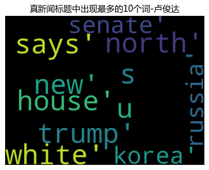

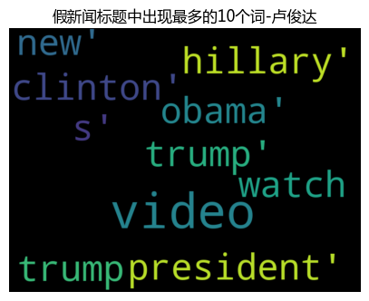

```python
# 下载停用词
nltk.download('stopwords')
stop_words = set(stopwords.words('english'))

# 从True.csv和Fake.csv中分别提取title列
true_titles = true_df['title']
fake_titles = fake_df['title']

# 分词并移除停用词
true_words = [word for title in true_titles for word in title.lower().split() if word not in stop_words]
fake_words = [word for title in fake_titles for word in title.lower().split() if word not in stop_words]

# 统计单词频率
true_word_counts = Counter(true_words)
fake_word_counts = Counter(fake_words)

# 提取出现次数最高的10个单词
top_true_words = true_word_counts.most_common(10)
top_fake_words = fake_word_counts.most_common(10)



# 绘制词云
wordcloud = WordCloud(width=800, height=600, random_state=18, max_font_size=110).generate(str(top_true_words))
plt.figure(figsize=(5, 5))
plt.imshow(wordcloud, interpolation="bilinear")
plt.axis('off')
plt.title('真新闻标题中出现最多的10个词-卢俊达', fontproperties=font)
plt.show()

wordcloud = WordCloud(width=800, height=600, random_state=18, max_font_size=110).generate(str(top_fake_words))
plt.figure(figsize=(5, 5))
plt.imshow(wordcloud, interpolation="bilinear")
plt.axis('off')
plt.title('假新闻标题中出现最多的10个词-卢俊达', fontproperties=font)
plt.show()
```

提取真假新闻文本中出现频率最多的20个词并绘制词云

[figure not shown]

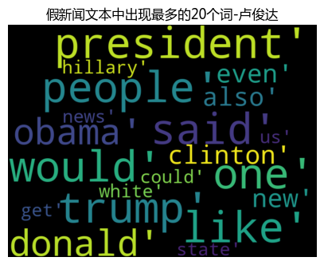

```python
# 下载停用词
nltk.download('stopwords')
stop_words = set(stopwords.words('english'))

# 从True.csv和Fake.csv中分别提取text列
true_titles = true_df['text']
fake_titles = fake_df['text']

# 分词并移除停用词
true_words = [word for title in true_titles for word in title.lower().split() if word not in stop_words]
fake_words = [word for title in fake_titles for word in title.lower().split() if word not in stop_words]

# 统计单词频率
true_word_counts = Counter(true_words)
fake_word_counts = Counter(fake_words)

# 提取出现次数最高的10个单词
top_true_words = true_word_counts.most_common(20)
top_fake_words = fake_word_counts.most_common(20)

# 绘制词云
wordcloud = WordCloud(width=800, height=600, random_state=18, max_font_size=110).generate(str(top_true_words))
plt.figure(figsize=(5, 5))
plt.imshow(wordcloud, interpolation="bilinear")
plt.axis('off')
plt.title('真新闻文本中出现最多的20个词-卢俊达', fontproperties=font)
plt.show()

wordcloud = WordCloud(width=800, height=600, random_state=18, max_font_size=110).generate(str(top_fake_words))
plt.figure(figsize=(5, 5))
plt.imshow(wordcloud, interpolation="bilinear")
plt.axis('off')
plt.title('假新闻文本中出现最多的20个词-卢俊达', fontproperties=font)
plt.show()
```

3-1.特征分析 通过数据的可视化，可以直观地看出在数据集的各个变量中，有些变量重合概率肉眼可见的高，可能不是真正需要的数据，如果能进一步判断，就可以找到需要的特征与不需要的特征以便进行后续工作。

3-2.特征处理与可视化

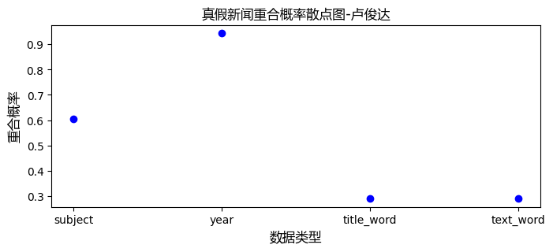

```python
# 计算真假新闻发布分类的重合概率

# 计算'politicsNews'元素的个数
fake_subjects_counts = Counter(fake_subjects)
fake_total_counts = 0
for subject, count in fake_subjects_counts.items():
    if subject == 'politics':
        fake_total_counts += count
    elif subject == 'News':
        fake_total_counts += count

true_subjects_counts = Counter(true_subjects)
politicsNews_count = 0
for subject, count in true_subjects_counts.items():
    if subject == 'politicsNews':
        politicsNews_count = count

# 计算总元素个数
fake_ele_count = len(fake_subjects)
true_ele_count = len(true_subjects)
total_ele_count = fake_ele_count+true_ele_count

subject_overlap = (fake_total_counts + politicsNews_count) / total_ele_count

# 计算真假新闻发布年份的重合概率

# 计算2016、2017年真假新闻个数
true_year_counts = Counter(true_years)
true_year_count = 0
for year, count in true_year_counts.items():
    true_year_count += count

fake_year_counts = Counter(fake_years)
fake_year_count = 0
for year, count in fake_year_counts.items():
    if year == 2016.0:
        fake_year_count += count
    elif year == 2017.0:
        fake_year_count += count

# 计算总元素个数
true_ele_count = len(true_years)
fake_ele_count = len(fake_years)
total_ele_count = true_ele_count + fake_ele_count

# 计算重合个数
overlap_count_1617 = true_year_count + fake_year_count
# 计算真假新闻发布年份的重合概率
year_overlap = overlap_count_1617 / total_ele_count

# 提取真假新闻标题中出现最多次数的10个词
top_true_title_words = [word[0] for word in top_true_words]
top_fake_title_words = [word[0] for word in top_fake_words]

# 计算真假新闻标题中出现最多次数的10个词语的重合概率
title_word_overlap = len(set(top_true_title_words) & set(top_fake_title_words)) / len(set(top_true_title_words).union(set(top_fake_title_words)))

# 提取真假新闻文本中出现最多次数的10个词
top_true_text_words = [word[0] for word in top_true_words]
top_fake_text_words = [word[0] for word in top_fake_words]

# 计算真假新闻文本中出现最多次数的10个词语的重合概率
text_word_overlap = len(set(top_true_text_words) & set(top_fake_text_words)) / len(set(top_true_text_words).union(set(top_fake_text_words)))

# 将这四个概率绘制成散点图
plt.figure(figsize=(8, 3))
plt.scatter(['subject', 'year', 'title_word', 'text_word'], [subject_overlap, year_overlap, title_word_overlap, text_word_overlap], color='b')
plt.xlabel('数据类型', fontproperties=font)
plt.ylabel('重合概率', fontproperties=font)
plt.title('真假新闻重合概率散点图-卢俊达', fontproperties=font)
plt.show()
```

由散点图可以看出，真假新闻的发布年份、发布类别重合概率太高了，不利于我们训练模型进行判别真假新闻，所以将这两个变量筛去。

```python
df.drop(['subject', 'date'], axis=1, inplace=True)
df.head(10)
```

|  | title | text | label |
| --- | --- | --- | --- |
| 0 | Crimean Tatar leader jailed for stirring anti-... | SIMFEROPOL, Crimea (Reuters) - A man who led p... | 0 |
| 1 | Police arrest two more men over London train b... | LONDON (Reuters) - British police said they ha... | 0 |
| 2 | Trump shows interest in bipartisan tax reform ... | WASHINGTON (Reuters) - President Donald Trump ... | 0 |
| 3 | Turkey's Justice Ministry says it canceled del... | ISTANBUL (Reuters) - Turkey s Justice Ministry... | 0 |
| 4 | Powerful Afghan regional leader ousted as poli... | KABUL (Reuters) - One of Afghanistan s most po... | 0 |
| 5 | UK PM May: We will not revoke Article 50 EU ex... | LONDON (Reuters) - Britain will not revoke the... | 0 |
| 6 | Josh Groban Mocks The Hell Out Trump Meeting ... | Because nothing in this world makes sense anym... | 1 |
| 7 | THE PURGE: NYC Mayor De Blasio to Review ‘All ... | THE PURGE CONTINUES THE NYC MAYOR has just ope... | 1 |
| 8 | Trump tells Congress: 'Get ready to do your jo... | WASHINGTON (Reuters) - U.S. President Donald T... | 0 |
| 9 | Alt-Right ‘Enemies’ List LEAKED: Fascists Use... | Last night Buzzfeed reported that a massive do... | 1 |

4.模型选择与训练 在这里，使用RandomForestClassifier 用于创建随机森林分类器的算法进行模型训练。 其中，将整个数据集划分为60%的训练集和40%的测试集分别用于训练模型和测试模型

```python
X = df[['title', 'text']]
y = df['label']

X_train, X_test, y_train, y_test = train_test_split(X, y, test_size=0.4, random_state=36)
```

```python
tfidf_vectorizer = TfidfVectorizer()
X_train_tfidf = tfidf_vectorizer.fit_transform(X_train['title'] + " " + X_train['text'])
X_test_tfidf = tfidf_vectorizer.transform(X_test['title'] + " " + X_test['text'])
```

```python
rf_classifier = RandomForestClassifier(random_state=36)
```

```python
rf_classifier.fit(X_train_tfidf, y_train)
```

```
RandomForestClassifier(random_state=36)
```

5.测试模型与总结 使用测试集对训练的模型进行测试

```python
y_pred = rf_classifier.predict(X_test_tfidf)
accuracy = accuracy_score(y_test, y_pred)
print("模型预测结果:")
print(y_pred)
print("模型准确率: {:.2f}%".format(accuracy * 100))
```

```
模型预测结果:
[1 0 0 ... 0 0 1]
模型准确率: 99.01%
```

现在，定义一个用于判断真假新闻的函数进一步检测模型 使用AI工具Copilot辅助生成了三条假新闻，交由模型判断

```python
def predict_news(title, text):
    # preprocess input
    input_data = tfidf_vectorizer.transform([title + " " + text])
    # make prediction
    pred =rf_classifier.predict(input_data)
    if pred[0]==0:
        return "Real News"
    else:
        return "Fake News"
```

三则新闻均是不符合事实的，所以预期结果应均为：Fake News

```python
input_title = "Giant Pandas Invade New York City"
input_text = "In a surprising turn of events, giant pandas were spotted roaming the streets of New York City, munching on bamboo, posing for selfies with tourists in Times Square, leaving authorities scrambling to contain the situation, and prompting residents to stay indoors to avoid potential aggression."
pred1 = predict_news(input_title,input_text)
print(pred1)
```

```
Fake News
```

```python
input_title = "Moon Made of Cheese Confirmed by NASA"
input_text = "NASA scientists have discovered that the moon is made of cheese, sparking worldwide cheese celebrations and anticipation for a manned mission to sample its dairy delights."
pred2 = predict_news(input_title,input_text)
print(pred2)
```

```
Fake News
```

```python
input_title = "Giant Puppies Take Over London's Underground"
input_text = "Adorable giant puppies cause chaos on London Underground; transport authorities baffled, residents advised to carry treats to prevent disruption."
pred3 = predict_news(input_title,input_text)
print(pred3)
```

```
Fake News
```

测试结果均符合预期。

未来工作方向： 数据处理： 自动化和智能化数据预处理：随着数据量的增长和多样性的增加，未来的数据处理可能会更加注重自动化和智能化。这包括自动识别和处理缺失值、异常值，以及更智能地处理非结构化数据如文本、图像和语音等。 跨域数据集成和挖掘：未来的数据处理技术可能会更多地涉及跨域数据集成和挖掘，将来自不同领域和来源的数据进行整合，从中发现更多的模式和关联。 可视化： 可解释性和交互性的提升：随着深度学习等复杂模型的应用，可解释性变得越来越重要。未来的可视化技术可能会更加注重如何以更直观、可解释的方式展示模型的工作原理和决策过程。同时，交互性的提升一个重要的方向，使用户能够更灵活地与数据和模型进行交互。 多模态数据的可视化：未来的数据越来越多地是多模态的，包括文本、图像、语音等多种形式。可视化技术可能会更加注重如何有效地将这些多模态数据进行整合和展示。 模型训练： 自适应学习和增量学习：未来的模型训练可能会更加注重自适应学习和增量学习，即模型能够根据新的数据自动更新和调整，适应数据的变化和演化。 强化学习和迁移学习的结合：强化学习和迁移学习是两个重要的学习范式，未来的模型训练可能会更多地结合这两种方法，以实现更广泛的应用和更好的性能。 总的来说，未来数据处理、可视化和模型训练的发展方向将更加注重自动化、智能化和适应性，以应对日益增长和多样化的数据需求，并实现更加灵活、高效和可解释的数据分析和模型应用。